# 03 Linear Regression Workshop

Xanthe Walker

2025-08-05

## What is a Linear Model?

A linear model describes a relationship between a response variable and one or more predictor variables based on a sample.

For continuous variables: assesses whether the mean value of the response variable differs significantly between different values of the explanatory variables

For categorical explanatory variables: assesses whether the mean value of the response variable differs significantly between different levels (or groups) of explanatory variables

In this workshop, we’ll walk through how to fit different types of linear models in R, interpret their results, and evaluate their assumptions using the `sparrows.csv` dataset.

The dataset includes measurements of sparrows including weight, wing length, tarsus length, head length, age, sex, and observer identity.

```r
spar <- read.csv("../../Data files/sparrows.csv")
head(spar)
```

```
##   Species    Sex Wing Tarsus Head Culmen Nalospi Weight Observer Age
## 1    SSTS   Male 58.0   21.7 32.7   13.9    10.2   20.3        2   0
## 2    SSTS Female 56.5   21.1 31.4   12.2    10.1   17.4        2   0
## 3    SSTS   Male 59.0   21.0 33.3   13.8    10.0   21.0        2   0
## 4    SSTS   Male 59.0   21.3 32.5   13.2     9.9   21.0        2   0
## 5    SSTS   Male 57.0   21.0 32.5   13.8     9.9   19.8        2   0
## 6    SSTS Female 57.0   20.7 32.5   13.3     9.9   17.5        2   0
```

## Simple Linear Regression

Let’s start with a basic linear model to examine how wing length predicts sparrow weight.

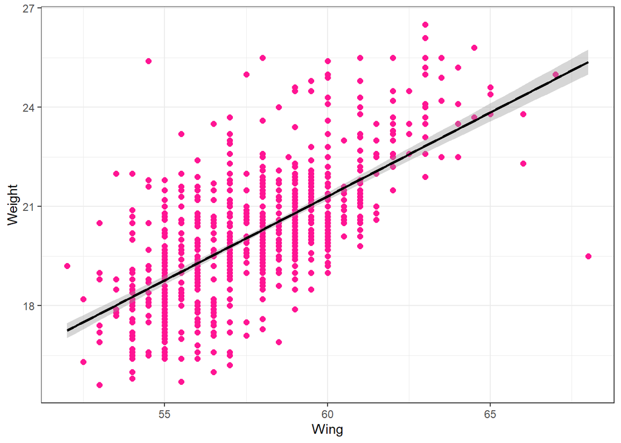

```r
ggplot(spar, aes(x = Wing, y = Weight)) +
  geom_point(size = 2, color = "deeppink") +
  geom_smooth(method = "lm", color = "black") +
  theme_bw()
```

```r
model1 <- lm(Weight ~ Wing, data = spar)
```

## Assessing Model Fits and Assumptions

Use built-in diagnostic plots to evaluate model assumptions:

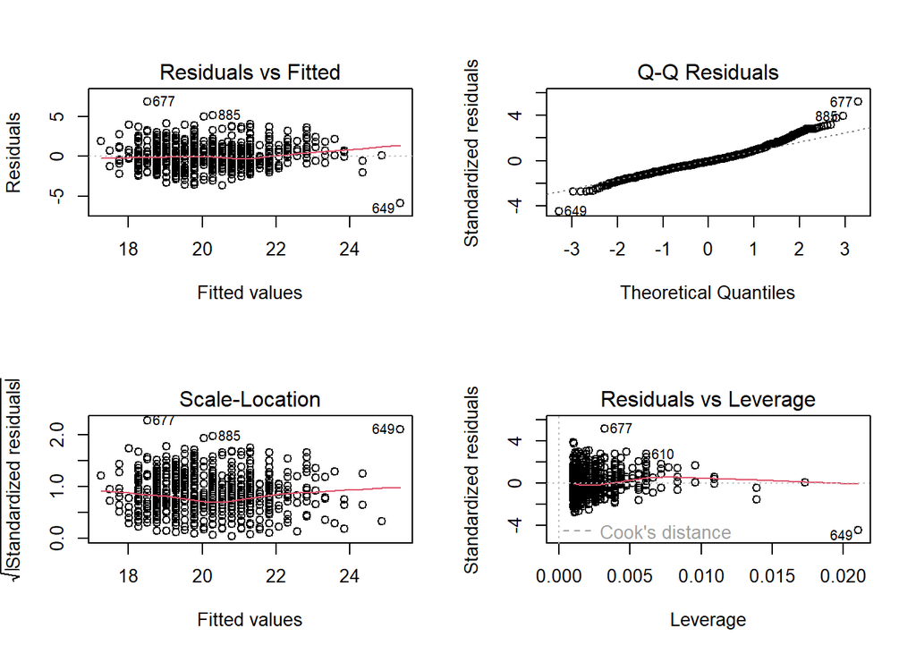

```r
par(mfrow = c(2, 2))
plot(model1)
```

Interpretation: - **Top-left (residuals vs fitted):** Look for nonlinearity or heteroscedasticity. - **Top-right (QQ plot):** Assesses normality of residuals. - **Bottom-left (scale-location):** Another check for homoscedasticity. - **Bottom-right (residuals vs leverage):** Identifies influential observations.

The other 3 plots all use standardized residuals, which are also typically referred to as studentized residuals.

The Q-Q plot shows quantiles of the standardized residuals versus quantiles of a standard normal distribution. If the normality assumption holds, we would expect to see the residuals largely fall along the dotted line indicating that the quantiles of the residuals (e.g., their 5th percentile, median, and 90th percentile, etc.) line up with the quantiles of the standard normal distribution.

The next plot is the square-root of absolute values of the standardized residuals versus fitted values. Here, we should see constant scatter along the x-axis if the constant variance assumption holds. Taking the absolute value of the residuals effectively reflects the negative residuals above the horizontal line y=0, making it easier to see departures from constant variance in small data sets.

The final plot shows residuals versus leverage, a measure of how far away each observation is in “predictor space” from the other observations. Observations with high leverage are often, but not always, highly influential points, meaning that deletion of these points leads to large changes in the regression parameters. In each of the panels, interesting and potentially problematic or influential points are indicated by their row number.

Alternatively, we coudl use the check_model function in sjPlot

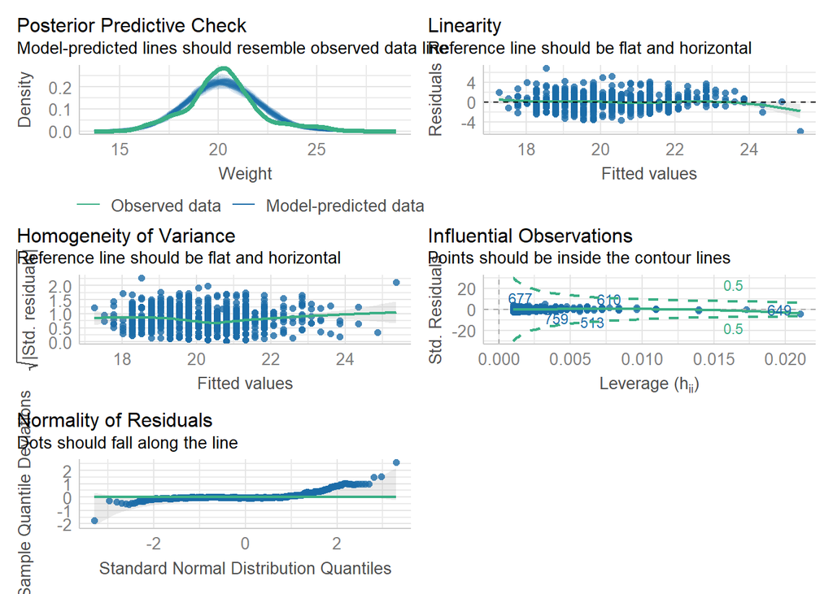

```r
check_model(model1)
```

## Extract coefficients from the model

```r
summary(model1)
```

```
##
## Call:
## lm(formula = Weight ~ Wing, data = spar)
##
## Residuals:
##     Min      1Q  Median      3Q     Max
## -5.8673 -0.7872 -0.1017  0.6910  6.8811
##
## Coefficients:
##             Estimate Std. Error t value Pr(>|t|)
## (Intercept) -9.12820    1.07459  -8.495   <2e-16 ***
## Wing         0.50729    0.01856  27.339   <2e-16 ***
## ---
## Signif. codes:  0 '***' 0.001 '**' 0.01 '*' 0.05 '.' 0.1 ' ' 1
##
## Residual standard error: 1.329 on 977 degrees of freedom
## Multiple R-squared:  0.4334, Adjusted R-squared:  0.4328
## F-statistic: 747.4 on 1 and 977 DF,  p-value: < 2.2e-16
```

```r
tab_model(model1)
```

|  | Weight |  |  |
| --- | --- | --- | --- |
| Predictors | Estimates | CI | p |
| (Intercept) | -9.13 | -11.24 – -7.02 | **<0.001** |
| Wing | 0.51 | 0.47 – 0.54 | **<0.001** |
| Observations | 979 |  |  |
| R<sup>2</sup> / R<sup>2</sup> adjusted | 0.433 / 0.433 |  |  |

The slope of the regression line is 0.51. This tells us that the average weight of sparrows change by 0.51 grams for each increase of 1 unit (mm) of wing length

More generally: The intercept = the average value of weight when all predictors are set equal to 0 (if our wing length is 0 mm then the weight is -9.13 grams) The slope = predicted change in Y per unit increase in X

## Test the hypothesis

Use anova to test the null hypohtesis that the slope = 0

```r
anova(model1)
```

```
## Analysis of Variance Table
##
## Response: Weight
##            Df Sum Sq Mean Sq F value    Pr(>F)
## Wing        1 1320.2 1320.17  747.39 < 2.2e-16 ***
## Residuals 977 1725.7    1.77
## ---
## Signif. codes:  0 '***' 0.001 '**' 0.01 '*' 0.05 '.' 0.1 ' ' 1
```

Under the null hypothesis that the slope is equal to 0, the ratio of 747.39 is unlikely (p < 0.001), and the null hypothesis can be rejected. The ANOVA table therefore provides a test to identify whether there is a linear relationship between Y and X.

## Model Comparison: Full vs. Reduced

Use ANOVA to compare a full model (with slope) to a reduced (null) model.

```r
null_model <- lm(Weight ~ 1, data = spar)
anova(null_model, model1)
```

```
## Analysis of Variance Table
##
## Model 1: Weight ~ 1
## Model 2: Weight ~ Wing
##   Res.Df    RSS Df Sum of Sq      F    Pr(>F)
## 1    978 3045.9
## 2    977 1725.7  1    1320.2 747.39 < 2.2e-16 ***
## ---
## Signif. codes:  0 '***' 0.001 '**' 0.01 '*' 0.05 '.' 0.1 ' ' 1
```

The anova function finds the factors that have been removed in the reduced model as compared to the full model, and tests whether those removed factors are different from zero.

## Plot the model results

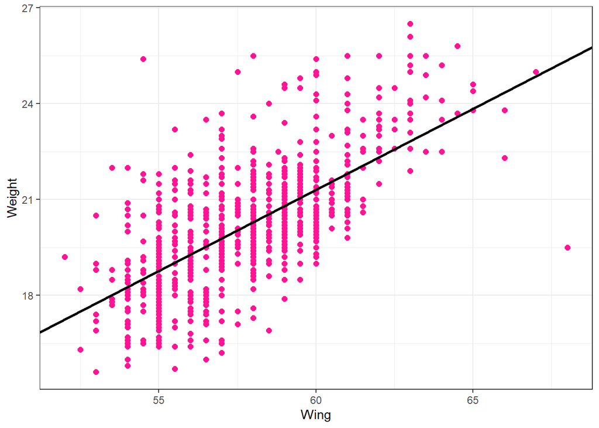

```r
g = ggplot(spar, aes(y=Weight, x=Wing)) + geom_point(size=2, color="deeppink") + theme_bw()
g= g+ geom_abline(linewidth=1, slope = coef(model1)[["Wing"]],intercept = coef(model1)[["(Intercept)"]])
g
```

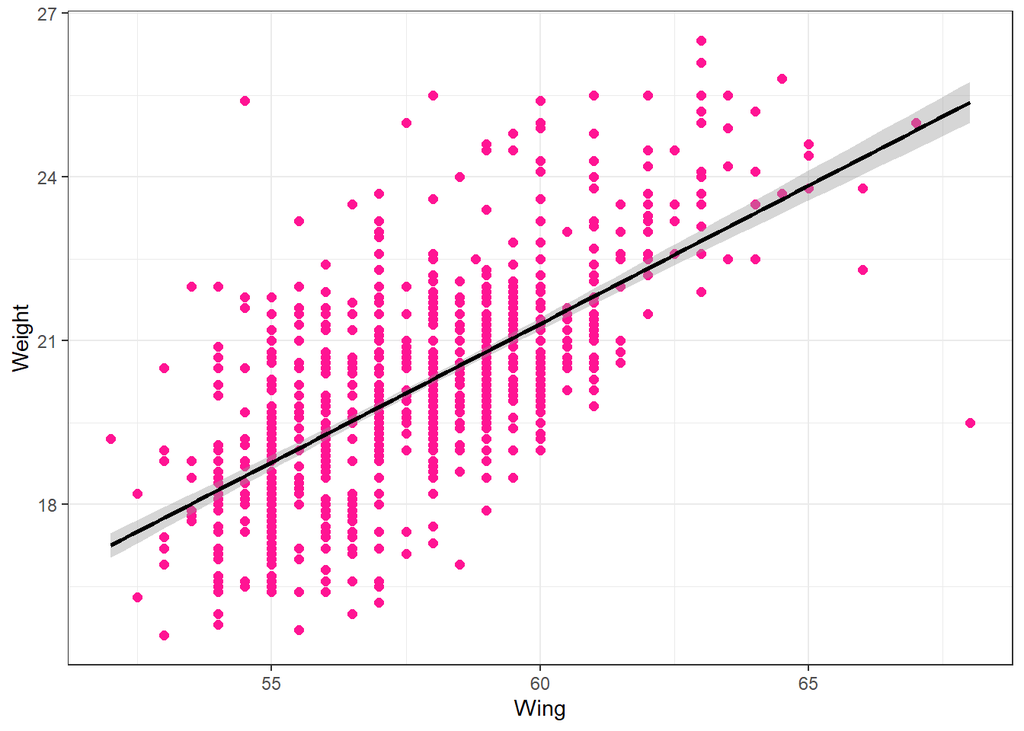

```r
#Note that we coudl also use the default ggplot - geom_smooth for simple linaer regression
g = ggplot(spar, aes(y=Weight, x=Wing)) + geom_point(size=2, color="deeppink") + theme_bw()
g= g+ geom_smooth(method="lm", color="black")
g
```

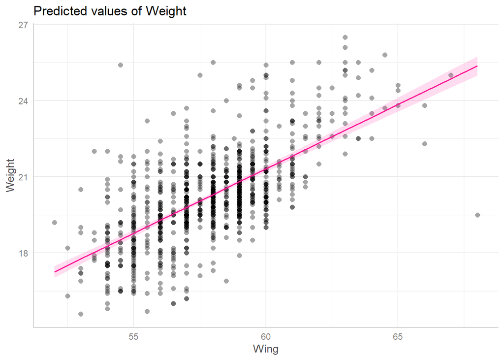

```r
# Scatterplot, model line, and 95%CI – useful for more complicated models
#default
m=ggpredict(model = model1, terms = c("Wing"))
plot(m, add.data=TRUE, color="deeppink")
```

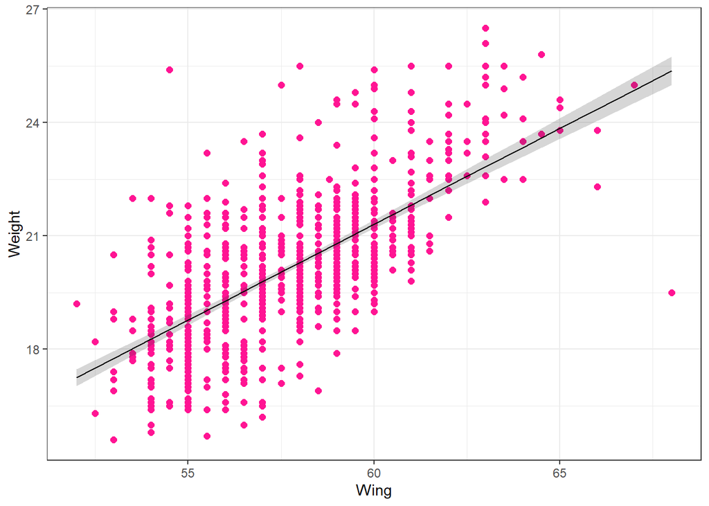

```r
#make it pretty :)
g=ggplot() + geom_point(data=spar, aes(y=Weight, x=Wing), color="deeppink", size=2) + theme_bw()
g=g+ geom_line(data=m, aes(y=predicted, x=x), color="black")
g=g+geom_ribbon(data=m, aes(x=x, ymin=conf.low, ymax=conf.high), alpha=0.2)
g
```

## Categorical Predictor (Two Levels)

Test whether weight differs by sex.

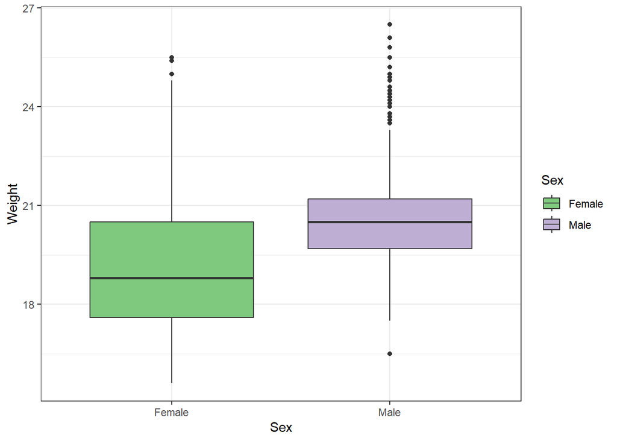

```r
spar$Sex <- as.factor(spar$Sex)
ggplot(spar, aes(x = Sex, y = Weight, fill = Sex)) +
  geom_boxplot() +
  scale_fill_brewer(palette = "Accent") +
  theme_bw()
```

```r
model2 <- lm(Weight ~ Sex, data = spar)
summary(model2)
```

```
##
## Call:
## lm(formula = Weight ~ Sex, data = spar)
##
## Residuals:
##     Min      1Q  Median      3Q     Max
## -4.1486 -1.0486 -0.2187  0.7514  6.2813
##
## Coefficients:
##             Estimate Std. Error t value Pr(>|t|)
## (Intercept)  19.2187     0.0965  199.15   <2e-16 ***
## SexMale       1.4299     0.1149   12.44   <2e-16 ***
## ---
## Signif. codes:  0 '***' 0.001 '**' 0.01 '*' 0.05 '.' 0.1 ' ' 1
##
## Residual standard error: 1.641 on 977 degrees of freedom
## Multiple R-squared:  0.1367, Adjusted R-squared:  0.1358
## F-statistic: 154.7 on 1 and 977 DF,  p-value: < 2.2e-16
```

```r
tab_model(model2)
```

|  | Weight |  |  |
| --- | --- | --- | --- |
| Predictors | Estimates | CI | p |
| (Intercept) | 19.22 | 19.03 – 19.41 | **<0.001** |
| Sex [Male] | 1.43 | 1.20 – 1.66 | **<0.001** |
| Observations | 979 |  |  |
| R<sup>2</sup> / R<sup>2</sup> adjusted | 0.137 / 0.136 |  |  |

```r
# this is equivalent to a t.test
t.test(Weight ~ Sex, data = spar)
```

```
##
##  Welch Two Sample t-test
##
## data:  Weight by Sex
## t = -10.79, df = 410.5, p-value < 2.2e-16
## alternative hypothesis: true difference in means between group Female and group Male is not equal to 0
## 95 percent confidence interval:
##  -1.690353 -1.169378
## sample estimates:
## mean in group Female   mean in group Male
##             19.21869             20.64855
```

## Categorical Predictor (More Than Two Levels)

Now explore variation in weight among different observers.

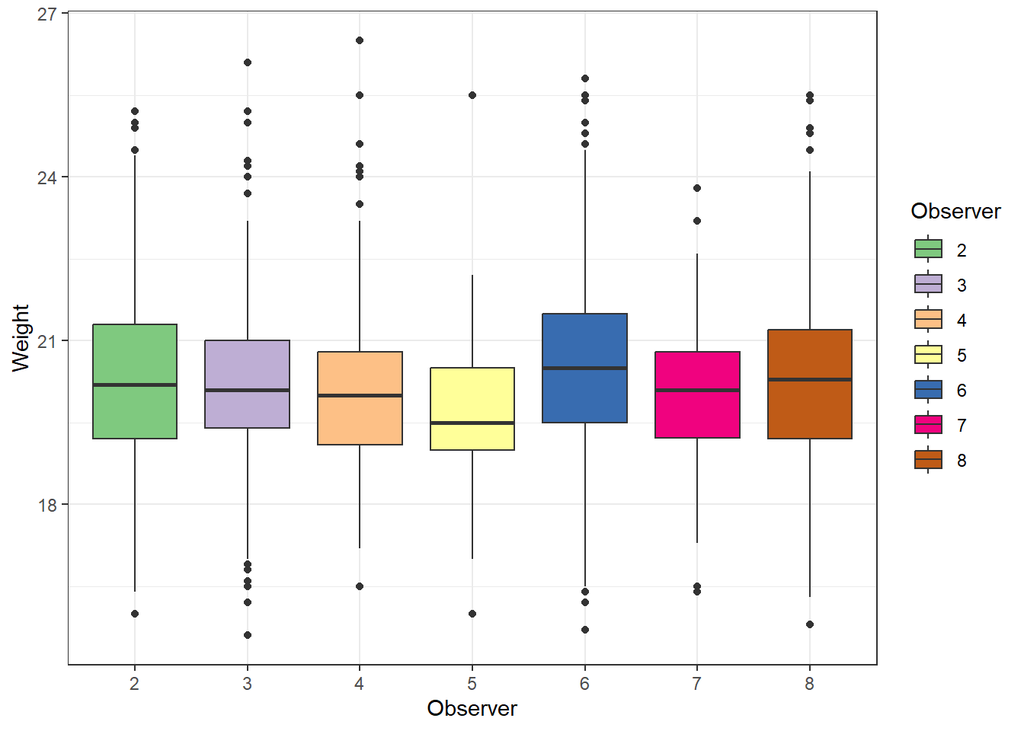

```r
spar$Observer <- as.factor(spar$Observer)
ggplot(spar, aes(x = Observer, y = Weight, fill = Observer)) +
  geom_boxplot() +
  scale_fill_brewer(palette = "Accent") +
  theme_bw()
```

```r
model3 <- lm(Weight ~ Observer, data = spar)
summary(model3)
```

```
##
## Call:
## lm(formula = Weight ~ Observer, data = spar)
##
## Residuals:
##     Min      1Q  Median      3Q     Max
## -4.7377 -0.9793 -0.0377  0.9207  6.2602
##
## Coefficients:
##              Estimate Std. Error t value Pr(>|t|)
## (Intercept) 20.237710   0.102350 197.730   <2e-16 ***
## Observer3   -0.058457   0.152923  -0.382   0.7023
## Observer4    0.002049   0.218999   0.009   0.9925
## Observer5   -0.531044   0.282160  -1.882   0.0601 .
## Observer6    0.199952   0.175153   1.142   0.2539
## Observer7   -0.195710   0.269630  -0.726   0.4681
## Observer8    0.053115   0.197533   0.269   0.7881
## ---
## Signif. codes:  0 '***' 0.001 '**' 0.01 '*' 0.05 '.' 0.1 ' ' 1
##
## Residual standard error: 1.764 on 972 degrees of freedom
## Multiple R-squared:  0.007147,   Adjusted R-squared:  0.001019
## F-statistic: 1.166 on 6 and 972 DF,  p-value: 0.3221
```

```r
# You should not trust these p-values to determine significance instead look at the F statistic for overall model fit
anova(model3)
```

```
## Analysis of Variance Table
##
## Response: Weight
##            Df  Sum Sq Mean Sq F value Pr(>F)
## Observer    6   21.77  3.6283  1.1662 0.3221
## Residuals 972 3024.13  3.1112
```

```r
# this is equivalent to completing an ANOVA
aov1=aov(data=spar, Weight~Observer)
summary(aov1)
```

```
##              Df Sum Sq Mean Sq F value Pr(>F)
## Observer      6   21.8   3.628   1.166  0.322
## Residuals   972 3024.1   3.111
```

These findigns do not support our hypothesis. There is no difference among observers.

If there were differences, we woudl need to comple post-hoc pairwise comparisons:

```r
emm <- emmeans(model3, ~Observer)
pairs(emm)
```

```
##  contrast              estimate    SE  df t.ratio p.value
##  Observer2 - Observer3  0.05846 0.153 972   0.382  0.9998
##  Observer2 - Observer4 -0.00205 0.219 972  -0.009  1.0000
##  Observer2 - Observer5  0.53104 0.282 972   1.882  0.4928
##  Observer2 - Observer6 -0.19995 0.175 972  -1.142  0.9151
##  Observer2 - Observer7  0.19571 0.270 972   0.726  0.9910
##  Observer2 - Observer8 -0.05312 0.198 972  -0.269  1.0000
##  Observer3 - Observer4 -0.06051 0.224 972  -0.270  1.0000
##  Observer3 - Observer5  0.47259 0.286 972   1.650  0.6498
##  Observer3 - Observer6 -0.25841 0.182 972  -1.420  0.7910
##  Observer3 - Observer7  0.13725 0.274 972   0.501  0.9988
##  Observer3 - Observer8 -0.11157 0.204 972  -0.548  0.9981
##  Observer4 - Observer5  0.53309 0.327 972   1.633  0.6612
##  Observer4 - Observer6 -0.19790 0.240 972  -0.824  0.9825
##  Observer4 - Observer7  0.19776 0.316 972   0.626  0.9960
##  Observer4 - Observer8 -0.05107 0.257 972  -0.199  1.0000
##  Observer5 - Observer6 -0.73100 0.299 972  -2.446  0.1809
##  Observer5 - Observer7 -0.33533 0.362 972  -0.925  0.9685
##  Observer5 - Observer8 -0.58416 0.313 972  -1.869  0.5015
##  Observer6 - Observer7  0.39566 0.287 972   1.378  0.8136
##  Observer6 - Observer8  0.14684 0.221 972   0.665  0.9944
##  Observer7 - Observer8 -0.24883 0.301 972  -0.826  0.9823
##
## P value adjustment: tukey method for comparing a family of 7 estimates
```

Each row represents a different pairwise comparison identified by the label in the first column. By default, emmeans uses Tukey’s Honest Significant Difference (HSD) to adjust the p-values and confidence intervals associated with each comparison

## ANCOVA (Categorical and Continuous Predictors)

Fit a model with both continuous (wing) and categorical (sex) predictor plus their interaction:

```r
model4 <- lm(Weight ~ Wing * Sex, data = spar)
summary(model4)
```

```
##
## Call:
## lm(formula = Weight ~ Wing * Sex, data = spar)
##
## Residuals:
##     Min      1Q  Median      3Q     Max
## -5.7137 -0.7649 -0.0772  0.7018  6.9476
##
## Coefficients:
##               Estimate Std. Error t value Pr(>|t|)
## (Intercept)  -14.95386    2.53165  -5.907 4.82e-09 ***
## Wing           0.61296    0.04539  13.505  < 2e-16 ***
## SexMale        6.59958    2.98288   2.212   0.0272 *
## Wing:SexMale  -0.11931    0.05273  -2.263   0.0239 *
## ---
## Signif. codes:  0 '***' 0.001 '**' 0.01 '*' 0.05 '.' 0.1 ' ' 1
##
## Residual standard error: 1.326 on 975 degrees of freedom
## Multiple R-squared:  0.4373, Adjusted R-squared:  0.4355
## F-statistic: 252.6 on 3 and 975 DF,  p-value: < 2.2e-16
```

```r
anova(model4)
```

```
## Analysis of Variance Table
##
## Response: Weight
##            Df  Sum Sq Mean Sq  F value  Pr(>F)
## Wing        1 1320.17 1320.17 750.9752 < 2e-16 ***
## Sex         1    2.74    2.74   1.5609 0.21184
## Wing:Sex    1    9.00    9.00   5.1201 0.02387 *
## Residuals 975 1713.99    1.76
## ---
## Signif. codes:  0 '***' 0.001 '**' 0.01 '*' 0.05 '.' 0.1 ' ' 1
```

```r
# Type III ANOVA to assess main effects while accounting for interaction
Anova(model4, type = 3)
```

```
## Anova Table (Type III tests)
##
## Response: Weight
##              Sum Sq  Df  F value    Pr(>F)
## (Intercept)   61.33   1  34.8900 4.815e-09 ***
## Wing         320.60   1 182.3733 < 2.2e-16 ***
## Sex            8.61   1   4.8951   0.02716 *
## Wing:Sex       9.00   1   5.1201   0.02387 *
## Residuals   1713.99 975
## ---
## Signif. codes:  0 '***' 0.001 '**' 0.01 '*' 0.05 '.' 0.1 ' ' 1
```

Note: The first ANOVA shown above is a **Type I (sequential)** ANOVA, which means each term is tested after accounting for the ones that precede it in the formula. Since the interaction is listed after both main effects, it is tested last, and main effects are tested without adjusting for the interaction.

To visualize the interaction and understand what it means, we can use an interaction plot:

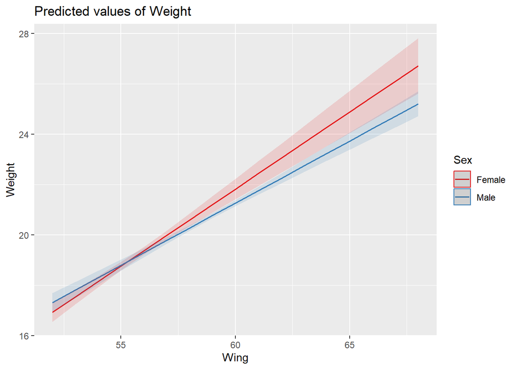

```r
plot_model(model4, type = "pred", terms = c("Wing", "Sex"))
```

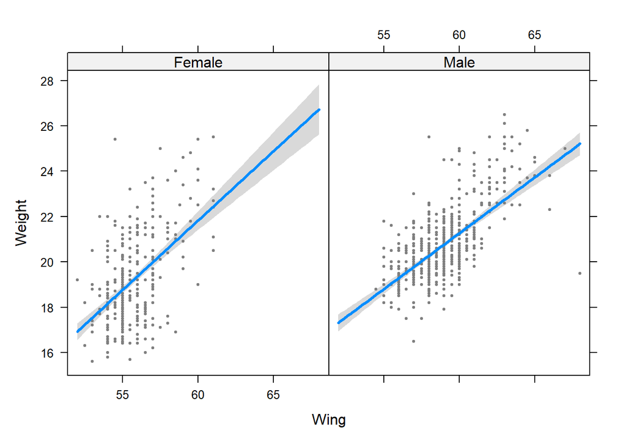

```r
visreg(model4, "Wing", by = "Sex")
```

To statistically test whether the **slopes** differ between groups (i.e., whether the interaction is significant), we use `emtrends()` from the `emmeans` package:

```r
# Estimate slope for each sex group and test if slopes differ
slope_tests <- emtrends(model4, ~ Sex, var = "Wing")

# Compare slopes between sexes (test interaction)
pairs(slope_tests)
```

```
##  contrast      estimate     SE  df t.ratio p.value
##  Female - Male    0.119 0.0527 975   2.263  0.0239
```

If the confidence intervals for the difference in slopes do not include zero, we have evidence that the effect of wing length on weight differs by sex.

To assess whether the slope of `Wing` is significantly different from zero within each `Sex` group, use the `test()` function from the `emmeans` package. This will extract significance tests for each slope estimate:

```r
test(slope_tests)
```

```
##  Sex    Wing.trend     SE  df t.ratio p.value
##  Female      0.613 0.0454 975  13.505  <.0001
##  Male        0.494 0.0268 975  18.395  <.0001
```

This output provides the estimated slopes, standard errors, t-values, and p-values for each group. A p-value < 0.05 indicates that wing length is a significant predictor of weight for that sex.

## Multiple Linear Regression

```r
model5 <- lm(Weight~Wing+Tarsus+Head, data = spar)
summary(model5)
```

```
##
## Call:
## lm(formula = Weight ~ Wing + Tarsus + Head, data = spar)
##
## Residuals:
##     Min      1Q  Median      3Q     Max
## -4.0298 -0.6723 -0.0770  0.6045  6.9316
##
## Coefficients:
##              Estimate Std. Error t value Pr(>|t|)
## (Intercept) -21.39915    1.29452 -16.531  < 2e-16 ***
## Wing          0.30029    0.02036  14.748  < 2e-16 ***
## Tarsus        0.48206    0.05915   8.150 1.11e-15 ***
## Head          0.43374    0.05603   7.742 2.45e-14 ***
## ---
## Signif. codes:  0 '***' 0.001 '**' 0.01 '*' 0.05 '.' 0.1 ' ' 1
##
## Residual standard error: 1.168 on 975 degrees of freedom
## Multiple R-squared:  0.563,  Adjusted R-squared:  0.5617
## F-statistic: 418.7 on 3 and 975 DF,  p-value: < 2.2e-16
```

```r
Anova(model5, type=2)
```

```
## Anova Table (Type II tests)
##
## Response: Weight
##            Sum Sq  Df F value    Pr(>F)
## Wing       296.94   1 217.508 < 2.2e-16 ***
## Tarsus      90.68   1  66.419 1.112e-15 ***
## Head        81.82   1  59.932 2.450e-14 ***
## Residuals 1331.07 975
## ---
## Signif. codes:  0 '***' 0.001 '**' 0.01 '*' 0.05 '.' 0.1 ' ' 1
```

When we include multiple continuous predictors, it’s important to determine whether each contributes uniquely to the model. Because we are interested in assessing the effect of each predictor *after accounting for the others*, we use a **Type II ANOVA**, which tests each term after adjusting for all others — but **not** after any interactions, as in Type III.

Type II ANOVA is most appropriate when: - There are no interaction terms in the model - Predictors are not orthogonal (i.e., they’re correlated) - We want to understand marginal effects of each variable, controlling for the others

We can visualize the predictions from this model using `ggeffects`. Here is an example for Wing, but this is easy to modify for the other predictor.

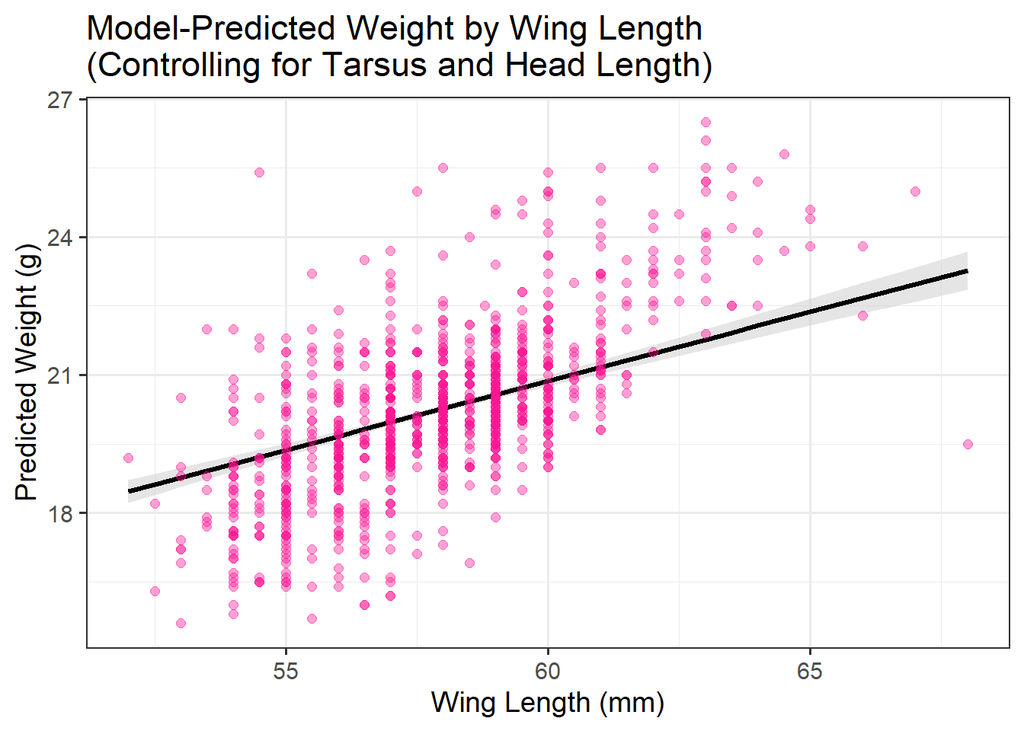

```r
pred <- ggpredict(model5, terms = "Wing [all]")

# Clean plot with confidence ribbon
ggplot(pred, aes(x = x, y = predicted)) +
  geom_ribbon(aes(ymin = conf.low, ymax = conf.high), fill = "grey80", alpha = 0.5) +
  geom_line(color = "black", size = 1.2) +
  geom_point(data = spar, aes(x = Wing, y = Weight), color = "deeppink", alpha = 0.4, size = 2) +
  labs(x = "Wing Length (mm)", y = "Predicted Weight (g)",
       title = "Model-Predicted Weight by Wing Length\n(Controlling for Tarsus and Head Length)") +
  theme_bw(base_size = 14)
```

## Standardizing Predictors

Standardizing (or scaling) predictors puts them on the same scale by subtracting the mean and dividing by the standard deviation. This is useful when predictors are measured in different units or when comparing their relative importance in a regression model. It also helps with numerical stability and interpretation of interaction terms.

```r
spar <- spar %>% mutate(across(c(Wing, Tarsus, Head), list(s = scale)))
model7 <- lm(Weight ~ Wing_s + Tarsus_s + Head_s, data = spar)
summary(model7)
```

```
##
## Call:
## lm(formula = Weight ~ Wing_s + Tarsus_s + Head_s, data = spar)
##
## Residuals:
##     Min      1Q  Median      3Q     Max
## -4.0298 -0.6723 -0.0770  0.6045  6.9316
##
## Coefficients:
##             Estimate Std. Error t value Pr(>|t|)
## (Intercept) 20.22646    0.03734 541.643  < 2e-16 ***
## Wing_s       0.68776    0.04663  14.748  < 2e-16 ***
## Tarsus_s     0.44527    0.05464   8.150 1.11e-15 ***
## Head_s       0.41561    0.05368   7.742 2.45e-14 ***
## ---
## Signif. codes:  0 '***' 0.001 '**' 0.01 '*' 0.05 '.' 0.1 ' ' 1
##
## Residual standard error: 1.168 on 975 degrees of freedom
## Multiple R-squared:  0.563,  Adjusted R-squared:  0.5617
## F-statistic: 418.7 on 3 and 975 DF,  p-value: < 2.2e-16
```

```r
car::vif(model7)
```

```
##   Wing_s Tarsus_s   Head_s
## 1.557892 2.138462 2.064661
```

The `summary()` output allows us to compare standardized regression coefficients directly, since all predictors are now on the same scale. This can help us evaluate which predictors have relatively stronger effects on the response variable.

We also calculate the Variance Inflation Factor (VIF) to assess multicollinearity. Values above 5–10 may indicate problematic collinearity between predictors.

## Summary

This workshop demonstrated how to: - Fit linear models in R using `lm()` - Interpret coefficients and model output - Evaluate assumptions - Compare models using ANOVA - Visualize results using `ggplot2`, `ggeffects`, and `visreg` - Apply models with categorical, continuous, and interaction terms - Use standardization to compare effects across predictors

These tools will form the foundation for more advanced modeling techniques later in the course.

## Exercises

### Exercise #1: One continous variable

We will start with simple linear regression using one continuous predictor. For this exercise use the dataset RIKZ. This is a data set from Zuur et al. (2009) containing abundances of ~ 75 invertebrate species measured on various beaches along the Dutch Coast. The data were originally published in Janssen & Mulder (2004) and Janssen & Mulder (2005).

In this study, the variable “NAP” measured the height of the sample site compared with average sea level, and indicated the time a site is under water. A site with a low NAP value will spend more time under water than a site with a high NAP value, and sites with high NAP values normally lie further up the beach. The authors wanted to know how species richness varied with NAP.

• Richness = species richness (i.e., the number of species counted). • NAP = height of the sample site (relative to sea level). Lower values indicate sites closer to or further below sea level, which implies more time spent submerged.

##### 1. 1. Read the data from the file “RIKZdat.csv”

##### 2. View the first few lines of data to make sure it was read correctly.

##### 3. Create a scatter plot of the data. Choose the response and explanatory variables with care: we want to predict Richness from height of the sample above sea level.

##### 4. Fit a linear model to the data with species richness (Richness) as the response variable and site height (NAP) as the predictor.

##### 5. Add the best-fit line to the scatter plot. Does the relationship appear linear? From the scatter plot, visually check for any serious problems such as outliers or changes in the variance.

##### 6. Using the same fitted model object, obtain the estimates for the coefficients, slope and intercept, standard errors, and 95% confidence intervals for the slope and intercept. What is the R2 value for the model fit? Hint: use tab_model function from the sjPlot package.

##### 7. Test the fit of the model to the data with an ANOVA table. What does this test tell us?

##### 8. Recall the assumptions of linear models. Do the data conform to the assumptions? Are there any potential concerns? Most of the plots will be self-explanatory, except perhaps the last one. “Leverage” calculates the influence that each data point has on the estimated parameters. For example, if the slope changes a great deal when a point is removed, that point is said to have high leverage. “Cook’s distance” measures the effect of each data point on the predicted values for all the other data points. A value greater than 1 is said to be worrisome. Points with high leverage don’t necessarily have high Cook’s distance, and vice versa.

## Exercise #2: One categorical variable

Our second example fits a linear model with a categorical explanatory variable. The data are from an experiment by Wright and Czeisler (2002. Science 297: 571) that re-examined a previous claim that light behind the knees could reset the circadian rhythm of an individual the same way as light to the eyes. One of three light treatments was randomly assigned to 22 subjects (a three-hour episode of bright lights to the eyes, to the knees, or to neither). Effects were measured two days later as the magnitude of phase shift in each subject’s daily cycle of melatonin production, measured in hours. A negative measurement indicates a delay in melatonin production, which is the predicted effect of light treatment.

##### 12. The P-values associated with the three coefficients are generally invalid. Why? Under what circumstance might one of the P-values be valid?

##### 13. Obtain 95% confidence intervals for the three parameters.

##### 14. Test the effect of light treatment on phase shift with an ANOVA table.

##### 15. Produce a table of the treatment means using the fitted model object, along with standard errors and confidence intervals. Hint: use the emmenas package. Now, calculate the means and SE’s separately on the data from each treatment group. When would you expect these values to be the same or different?

## Exercise #3: One categorical and one continuous variable

The data are from L. Partridge and M. Farquhar (1981), Sexual activity and the lifespan of male fruit flies, Nature 294: 580-581. The experiment placed male fruit flies with varying numbers of previously-mated or virgin females to investigate whether mating activity affects male lifespan.

The linear model will have longevity as the response variable, and two explanatory variables: treatment (categorical) and thorax length (numerical; representing body size). The goal will be to compare differences in fly longevity among treatment groups, correcting for differences in thorax length. Correcting for thorax length will possibly improve the estimates of treatment effect. The method is also known as analysis of covariance, or ANCOVA.

##### 15. Another way to help assess whether the assumption of no interaction is a sensible one for these data is to determine whether the fit of the model is “better” when an interaction term is present or not, and by how much. We will learn new methods later in the course to determine this, but in the meantime a simple measure of model fit can be obtained using the adjusted R2 value. The ordinary R2 measures the fraction of the total variation in the response variable that is “explained” by the explanatory variables. This, however, cannot be compared between models that differ in the number of parameters because fitting more parameters always results in a larger R2, even if the added variables are just made-up random numbers. To compare the fit of models having different parameters, use the adjusted R2 value instead, which takes account of the number of parameters being fitted. Use the summary() command on each of two fitted models, one with and the other without an interaction term, and compare their adjusted R2 values. Are they much different? If not, then maybe it is OK to assume that any interaction term is likely small and can be left out.